# IODS course project

# Chapter 3. Analysis exercise Logistic regression

## 2. Reading the data and describing the dataset

```r
alc <- read.table("https://raw.githubusercontent.com/KimmoVehkalahti/Helsinki-Open-Data-Science/master/datasets/alc.csv", sep = ",", header = TRUE)

colnames(alc)
```

```
##  [1] "school"     "sex"        "age"        "address"    "famsize"
##  [6] "Pstatus"    "Medu"       "Fedu"       "Mjob"       "Fjob"
## [11] "reason"     "guardian"   "traveltime" "studytime"  "schoolsup"
## [16] "famsup"     "activities" "nursery"    "higher"     "internet"
## [21] "romantic"   "famrel"     "freetime"   "goout"      "Dalc"
## [26] "Walc"       "health"     "failures"   "paid"       "absences"
## [31] "G1"         "G2"         "G3"         "alc_use"    "high_use"
```

The dataset explores student achievement in secondary education of two Portuguese schools. The data was collected using school reports and questionnaires. The performance in mathematics and portuguese language have been measudred and in addition the data included attributes such as demographic, social and school related features. In the dataset variable ‘alc_use’ is the average of ‘Dalc’ and ‘Walc’variables. ’high_use’ is TRUE if ‘alc_use’ is higher than 2 and FALSE otherwise.

More detailed description of the dataset can be read at: https://archive.ics.uci.edu/ml/datasets/Student+Performance

Some of the answers are binary (eg. yes/no), and others numeric (eg. on a scale of 1-5) or nominal (eg. mother/father/other)

## 3. Relationships between alcohol consumption and other variables

I chose four variables: studytime, activities, health, goout

- I hypothesize that if alcohol consumption is high, then a student would spend less time studying
- I hypopthesize that if a student takes extra-curricular acitivities, their alcohol consumption is lower
- I hypothesize that if students alcohol consumption is high, they rate their current health status as worse
- I hypothesize that if students alcohol consumption is high, they go out with friends more

## 4. Exploring the distributions of the variables

Comment on your findings and compare the results of your exploration to your previously stated hypotheses.

```r
library(tidyverse)
library(dplyr)
library(ggplot2)
library(readr)
library(gmodels)

## Cross tabulations
CrossTable(alc$high_use, alc$studytime)
```

```
##
##
##    Cell Contents
## |-------------------------|
## |                       N |
## | Chi-square contribution |
## |           N / Row Total |
## |           N / Col Total |
## |         N / Table Total |
## |-------------------------|
##
##
## Total Observations in Table:  370
##
##
##              | alc$studytime
## alc$high_use |         1 |         2 |         3 |         4 | Row Total |
## -------------|-----------|-----------|-----------|-----------|-----------|
##        FALSE |        56 |       128 |        52 |        23 |       259 |
##              |     2.314 |     0.017 |     2.381 |     0.889 |           |
##              |     0.216 |     0.494 |     0.201 |     0.089 |     0.700 |
##              |     0.571 |     0.692 |     0.867 |     0.852 |           |
##              |     0.151 |     0.346 |     0.141 |     0.062 |           |
## -------------|-----------|-----------|-----------|-----------|-----------|
##         TRUE |        42 |        57 |         8 |         4 |       111 |
##              |     5.400 |     0.041 |     5.556 |     2.075 |           |
##              |     0.378 |     0.514 |     0.072 |     0.036 |     0.300 |
##              |     0.429 |     0.308 |     0.133 |     0.148 |           |
##              |     0.114 |     0.154 |     0.022 |     0.011 |           |
## -------------|-----------|-----------|-----------|-----------|-----------|
## Column Total |        98 |       185 |        60 |        27 |       370 |
##              |     0.265 |     0.500 |     0.162 |     0.073 |           |
## -------------|-----------|-----------|-----------|-----------|-----------|
##
##
```

```r
CrossTable(alc$high_use, alc$activities)
```

```
##
##
##    Cell Contents
## |-------------------------|
## |                       N |
## | Chi-square contribution |
## |           N / Row Total |
## |           N / Col Total |
## |         N / Table Total |
## |-------------------------|
##
##
## Total Observations in Table:  370
##
##
##              | alc$activities
## alc$high_use |        no |       yes | Row Total |
## -------------|-----------|-----------|-----------|
##        FALSE |       120 |       139 |       259 |
##              |     0.224 |     0.210 |           |
##              |     0.463 |     0.537 |     0.700 |
##              |     0.670 |     0.728 |           |
##              |     0.324 |     0.376 |           |
## -------------|-----------|-----------|-----------|
##         TRUE |        59 |        52 |       111 |
##              |     0.523 |     0.490 |           |
##              |     0.532 |     0.468 |     0.300 |
##              |     0.330 |     0.272 |           |
##              |     0.159 |     0.141 |           |
## -------------|-----------|-----------|-----------|
## Column Total |       179 |       191 |       370 |
##              |     0.484 |     0.516 |           |
## -------------|-----------|-----------|-----------|
##
##
```

```r
CrossTable(alc$high_use, alc$health)
```

```
##
##
##    Cell Contents
## |-------------------------|
## |                       N |
## | Chi-square contribution |
## |           N / Row Total |
## |           N / Col Total |
## |         N / Table Total |
## |-------------------------|
##
##
## Total Observations in Table:  370
##
##
##              | alc$health
## alc$high_use |         1 |         2 |         3 |         4 |         5 | Row Total |
## -------------|-----------|-----------|-----------|-----------|-----------|-----------|
##        FALSE |        35 |        28 |        61 |        45 |        90 |       259 |
##              |     0.243 |     0.067 |     0.446 |     0.059 |     0.653 |           |
##              |     0.135 |     0.108 |     0.236 |     0.174 |     0.347 |     0.700 |
##              |     0.761 |     0.667 |     0.762 |     0.726 |     0.643 |           |
##              |     0.095 |     0.076 |     0.165 |     0.122 |     0.243 |           |
## -------------|-----------|-----------|-----------|-----------|-----------|-----------|
##         TRUE |        11 |        14 |        19 |        17 |        50 |       111 |
##              |     0.568 |     0.156 |     1.042 |     0.138 |     1.524 |           |
##              |     0.099 |     0.126 |     0.171 |     0.153 |     0.450 |     0.300 |
##              |     0.239 |     0.333 |     0.237 |     0.274 |     0.357 |           |
##              |     0.030 |     0.038 |     0.051 |     0.046 |     0.135 |           |
## -------------|-----------|-----------|-----------|-----------|-----------|-----------|
## Column Total |        46 |        42 |        80 |        62 |       140 |       370 |
##              |     0.124 |     0.114 |     0.216 |     0.168 |     0.378 |           |
## -------------|-----------|-----------|-----------|-----------|-----------|-----------|
##
##
```

```r
CrossTable(alc$high_use, alc$goout)
```

```
##
##
##    Cell Contents
## |-------------------------|
## |                       N |
## | Chi-square contribution |
## |           N / Row Total |
## |           N / Col Total |
## |         N / Table Total |
## |-------------------------|
##
##
## Total Observations in Table:  370
##
##
##              | alc$goout
## alc$high_use |         1 |         2 |         3 |         4 |         5 | Row Total |
## -------------|-----------|-----------|-----------|-----------|-----------|-----------|
##        FALSE |        19 |        82 |        97 |        40 |        21 |       259 |
##              |     0.842 |     2.928 |     2.012 |     3.904 |     6.987 |           |
##              |     0.073 |     0.317 |     0.375 |     0.154 |     0.081 |     0.700 |
##              |     0.864 |     0.845 |     0.808 |     0.513 |     0.396 |           |
##              |     0.051 |     0.222 |     0.262 |     0.108 |     0.057 |           |
## -------------|-----------|-----------|-----------|-----------|-----------|-----------|
##         TRUE |         3 |        15 |        23 |        38 |        32 |       111 |
##              |     1.964 |     6.832 |     4.694 |     9.109 |    16.303 |           |
##              |     0.027 |     0.135 |     0.207 |     0.342 |     0.288 |     0.300 |
##              |     0.136 |     0.155 |     0.192 |     0.487 |     0.604 |           |
##              |     0.008 |     0.041 |     0.062 |     0.103 |     0.086 |           |
## -------------|-----------|-----------|-----------|-----------|-----------|-----------|
## Column Total |        22 |        97 |       120 |        78 |        53 |       370 |
##              |     0.059 |     0.262 |     0.324 |     0.211 |     0.143 |           |
## -------------|-----------|-----------|-----------|-----------|-----------|-----------|
##
##
```

## Bar plots

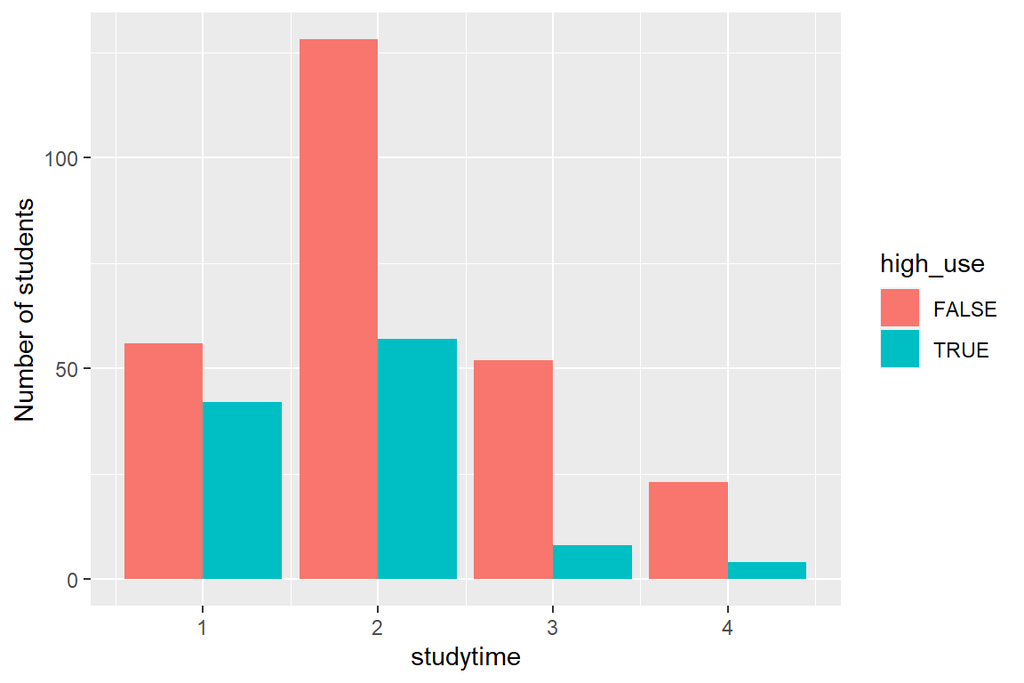

```r
studytime_barplot <- ggplot(data = alc, aes(x=studytime, fill = high_use))
studytime_barplot + geom_bar(position=position_dodge()) + labs(y="Number of students")
```

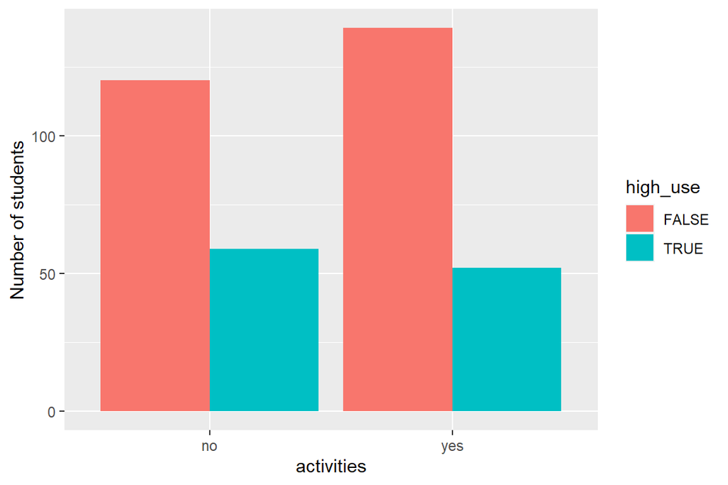

```r
activities_barplot <- ggplot(data = alc, aes(x=activities, fill = high_use))
activities_barplot + geom_bar(position=position_dodge()) + labs(y="Number of students")
```

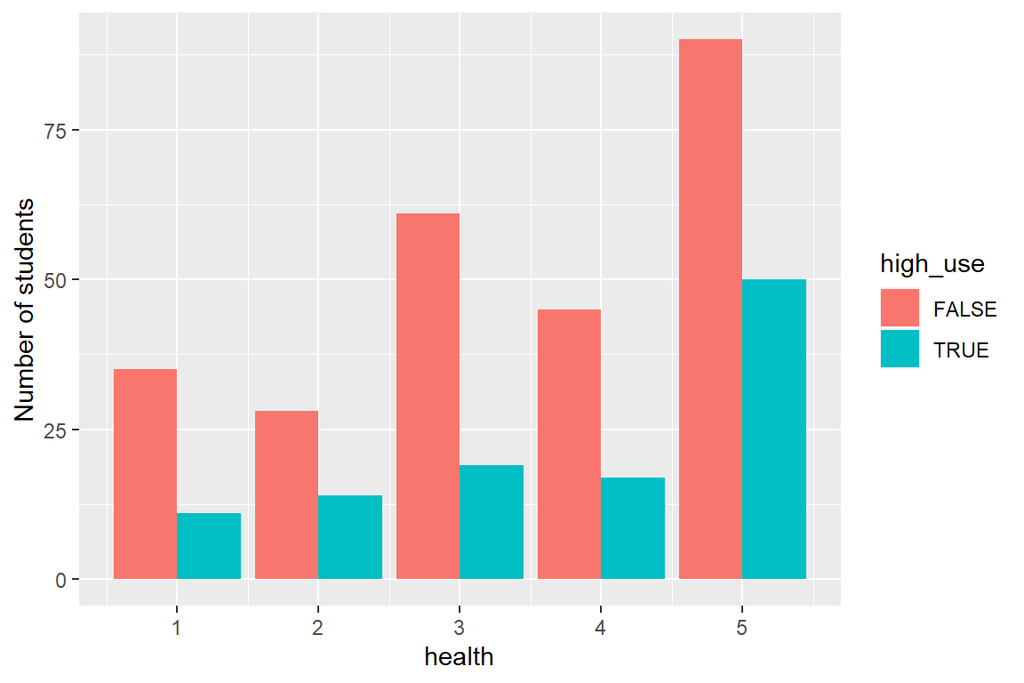

```r
health_barplot <- ggplot(data = alc, aes(x=health, fill = high_use))
health_barplot + geom_bar(position=position_dodge()) + labs(y="Number of students")
```

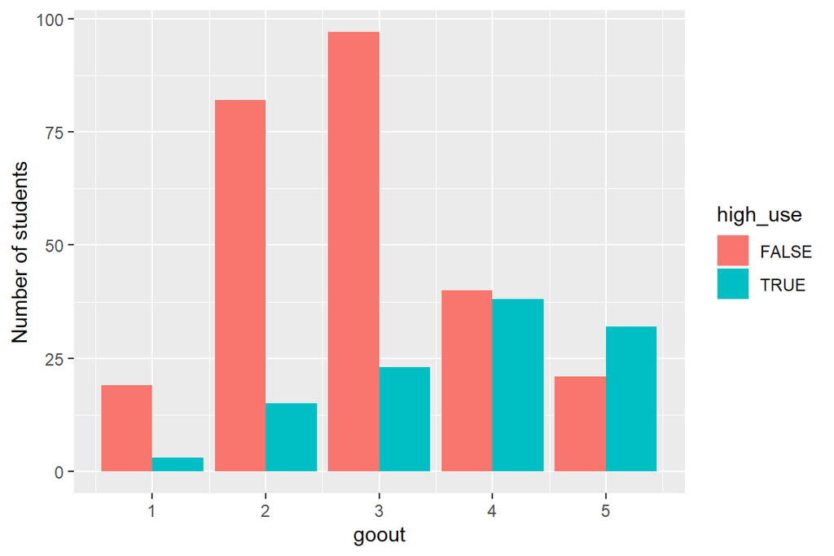

```r
goout_barplot <- ggplot(data = alc, aes(x=goout, fill = high_use))
goout_barplot + geom_bar(position=position_dodge()) + labs(y="Number of students")
```

## Box plots

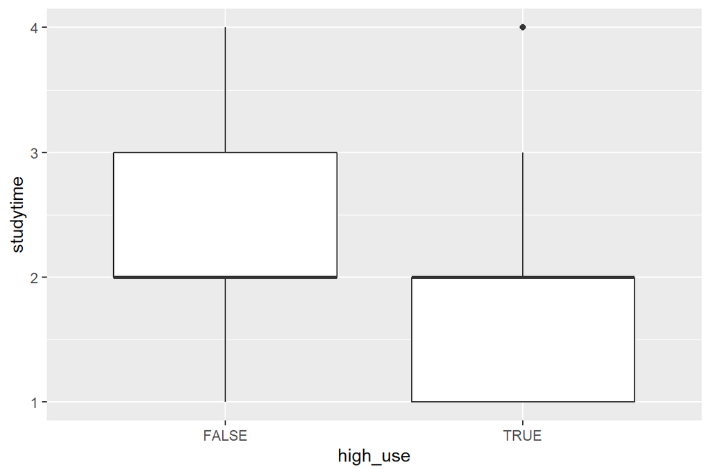

```r
studytime_boxplot <- ggplot(alc, aes(x = high_use, y = studytime))

# define the plot as a boxplot and draw it
studytime_boxplot + geom_boxplot()
```

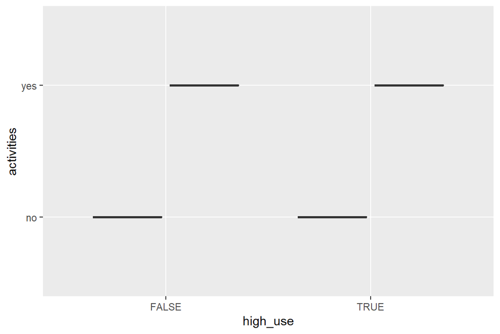

```r
activities_boxplot <- ggplot(alc, aes(x = high_use, y = activities))

activities_boxplot + geom_boxplot()
```

Boxplot makes no sense in this case as activities is a binary variable

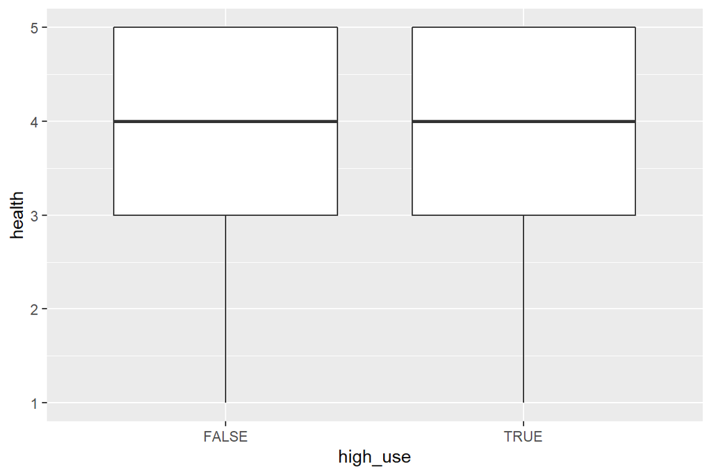

```r
health_boxplot <- ggplot(alc, aes(x = high_use, y = health))

health_boxplot + geom_boxplot()
```

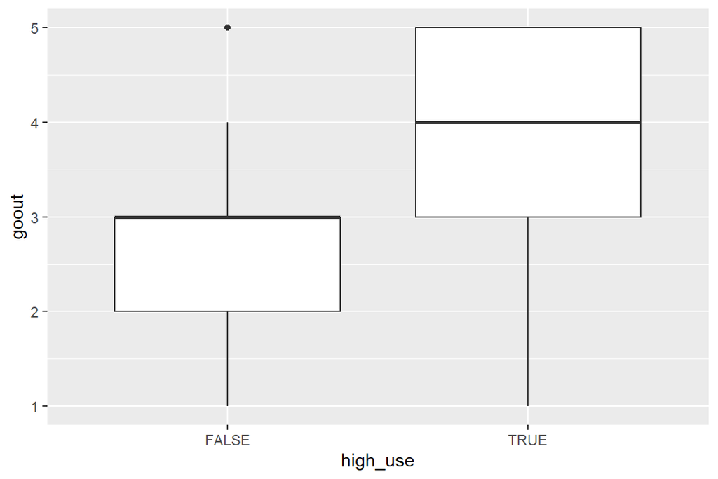

```r
goout_boxplot <- ggplot(alc, aes(x = high_use, y = goout))

goout_boxplot + geom_boxplot()
```

There seems to be an association between high_use and goout variables as well as high_use and studytime supporting my initial hypotheses. There doesn’t seem to be an association between health and amount alcohol use and activities and alcohol use.

## 5. Logistic regression

### Presenting and interpreting summary of the fitted model

Fitting the model

```r
m <- glm(high_use ~ studytime + activities + health + goout, data = alc, family = "binomial")
summary(m)
```

```
##
## Call:
## glm(formula = high_use ~ studytime + activities + health + goout,
##     family = "binomial", data = alc)
##
## Deviance Residuals:
##     Min       1Q   Median       3Q      Max
## -1.7878  -0.7844  -0.5507   0.9040   2.6331
##
## Coefficients:
##               Estimate Std. Error z value Pr(>|z|)
## (Intercept)   -2.54832    0.63687  -4.001  6.3e-05 ***
## studytime     -0.58926    0.16676  -3.534  0.00041 ***
## activitiesyes -0.30072    0.25281  -1.190  0.23423
## health         0.14004    0.09029   1.551  0.12090
## goout          0.76189    0.11894   6.406  1.5e-10 ***
## ---
## Signif. codes:  0 '***' 0.001 '**' 0.01 '*' 0.05 '.' 0.1 ' ' 1
##
## (Dispersion parameter for binomial family taken to be 1)
##
##     Null deviance: 452.04  on 369  degrees of freedom
## Residual deviance: 383.67  on 365  degrees of freedom
## AIC: 393.67
##
## Number of Fisher Scoring iterations: 4
```

The variables I thought were associated with high_use (studytime and goout) based on visual observation seem to be statistically significant as well based on this summary. For studytime there seems to be a negative association with high_use, meaning if the alcohol use is high, the probability of studying less is higher. High alcol use and going out with friends seem to be positively associated meaning that if the alcohol use is high, the probability of going more out with friends is higher.

###Presenting and interpreting the coefficients of the model as odds ratios

```r
# compute odds ratios (OR)
OR <- coef(m) %>% exp

# compute confidence intervals (CI)
CI <- confint(m)%>% exp
# print out the odds ratios with their confidence intervals
cbind(OR, CI)
```

```
##                       OR      2.5 %    97.5 %
## (Intercept)   0.07821325 0.02178097 0.2659023
## studytime     0.55473498 0.39563591 0.7621319
## activitiesyes 0.74028531 0.44966067 1.2138630
## health        1.15032068 0.96559347 1.3768670
## goout         2.14231738 1.70763719 2.7248784
```

In activities and health the confidence interval crosses 1, which means there is no association If the alcohol use is high, the probability of going out with friends is 2,14x higher. So none of the variables has very high odds ratio.

## 6. Exploring the predictive power of my model

```r
 # fit the model
m <- glm(high_use ~ studytime + goout, data = alc, family = "binomial")

# predict() the probability of high_use
probabilities <- predict(m, type = "response")

library(dplyr)
# add the predicted probabilities to 'alc'
alc <- mutate(alc, probability = probabilities)

# use the probabilities to make a prediction of high_use
alc <- mutate(alc, prediction = probability > 0.5)

# tabulate the target variable versus the predictions
table(high_use = alc$high_use, prediction = alc$prediction) %>% addmargins()
```

```
##         prediction
## high_use FALSE TRUE Sum
##    FALSE   238   21 259
##    TRUE     70   41 111
##    Sum     308   62 370
```

This means that my model of two statistically significant variables is not great at predicting high alcohol use. Other predictors would need to be added to create more accurate prediction. Among all predictions 91 were inaccurate.

### Computing the training error

```r
# define a loss function (mean prediction error)
loss_func <- function(class, prob) {
  n_wrong <- abs(class - prob) > 0.5
  mean(n_wrong)
}

# call loss_func to compute the average number of wrong predictions in the (training) data
loss_func(class = alc$high_use, prob = alc$probability)
```

```
## [1] 0.2459459
```

Computing average number of wrong predictions by random guess (uniform distribution from 0.0 to 1.0)

```r
alc <- mutate(alc, random_guess = runif(n()))
loss_func(class = alc$high_use, prob = alc$random_guess)
```

```
## [1] 0.472973
```

```r
# K-fold cross-validation
library(boot)
cv <- cv.glm(data = alc, cost = loss_func, glmfit = m, K = nrow(alc))

# average number of wrong predictions in the cross validation
cv$delta[1]
```

```
## [1] 0.2459459
```

This tells that 25% of predictions are wrong in this model. Random guess was wrong about 50% of the time and my model was wrong 25% of the time

## 7. BONUS

```r
# K-fold cross-validation
library(boot)
cv <- cv.glm(data = alc, cost = loss_func, glmfit = m, K = nrow(alc))

# average number of wrong predictions in the cross validation
cv$delta[1]
```

```
## [1] 0.2459459
```

```r
#10-fold cross validation
cv <- cv.glm(data = alc, cost = loss_func, glmfit = m, K = 10)
cv$delta[1]
```

```
## [1] 0.2459459
```

There was no big difference between K-fold cross-validation and 10-fold cross-validation. My model is slightly better than the model introduced in the exercise set. ***

```r
date()
```

```
## [1] "Fri Nov 25 21:10:33 2022"
```

# Chapter 4. Analysis exercise Clustering and classification

```r
library(tidyverse)
#install.packages(c("MASS", "corrplot"))
```

## Loading the Boston data from the MASS package

```r
library(MASS)
data("Boston")
```

## 2. Exploring the structure and the dimensions of the data and describing the dataset

```r
str(Boston)
```

```
## 'data.frame':    506 obs. of  14 variables:
##  $ crim   : num  0.00632 0.02731 0.02729 0.03237 0.06905 ...
##  $ zn     : num  18 0 0 0 0 0 12.5 12.5 12.5 12.5 ...
##  $ indus  : num  2.31 7.07 7.07 2.18 2.18 2.18 7.87 7.87 7.87 7.87 ...
##  $ chas   : int  0 0 0 0 0 0 0 0 0 0 ...
##  $ nox    : num  0.538 0.469 0.469 0.458 0.458 0.458 0.524 0.524 0.524 0.524 ...
##  $ rm     : num  6.58 6.42 7.18 7 7.15 ...
##  $ age    : num  65.2 78.9 61.1 45.8 54.2 58.7 66.6 96.1 100 85.9 ...
##  $ dis    : num  4.09 4.97 4.97 6.06 6.06 ...
##  $ rad    : int  1 2 2 3 3 3 5 5 5 5 ...
##  $ tax    : num  296 242 242 222 222 222 311 311 311 311 ...
##  $ ptratio: num  15.3 17.8 17.8 18.7 18.7 18.7 15.2 15.2 15.2 15.2 ...
##  $ black  : num  397 397 393 395 397 ...
##  $ lstat  : num  4.98 9.14 4.03 2.94 5.33 ...
##  $ medv   : num  24 21.6 34.7 33.4 36.2 28.7 22.9 27.1 16.5 18.9 ...
```

```r
dim(Boston)
```

```
## [1] 506  14
```

This is a dataset already loaded in R that is used often for teaching purposes. The dataset has 506 observations of 14 variables, 506 rows and 14 columns. The dataset explores Housing Values in Suburbs of Boston. The variables include for example per capita crime rate by town, weighted mean of distances to five Boston employment centres and pupil-teacher ratio by town. More about the dataset can be read here: https://stat.ethz.ch/R-manual/R-devel/library/MASS/html/Boston.html